# Shawn Garbett

[figure not shown]

*“The crux of the biscuit is the apostrophe.”* –Frank Zappa

For those wanting all the details, take a look at my resume or my curriculum vitae(CV). To contact me decode this puzzle: ‘shawn <dot> garbett <at> vumc.org’ or ‘shawn <at> garbett.org’ for personal correspondence.

## The Long and Short of It

I am infinitely curious and highly resourceful. I love playing piano, board games, modeling, reading sci fi, and programming. One theme through all these years is modeling–whether it be simulating nuclear magnetic resonance, playing an abstract simulation game or building a scale car and painting it. A statistical model of data is another model I enjoy, and these prove to be highly useful and lucrative.

*Preciso Me Encontrar* performed by Buffy Rhea and myself.

[interactive chart not shown]

Fluent in a wide variety of programming languages and technology stacks. However, what I really enjoy is formally typed languages like Haskell. It’s incredible that via the [Curry-Howard correspondence](https://en.wikipedia.org/wiki/Curry%E2%80%93Howard_correspondence) each program is a witness to the proof of that program’s type. That type may be something utterly useless and broken, but one has never the less proved it. Dependent type systems of proof via [Homotopy Type Theory](https://homotopytypetheory.org/) is a personal fascination.

If we only knew what [it](https://youtu.be/5DlTexEXxLQ?si=xy3wOmpC7IJ2_sOg) was.

If one needs predictive or explanatory statistical data science models of data; this I can deliver. Applied economic decision making with dimensions of cost and effectiveness is a specialty.

I’ve seen several presentations where predictive models are referred to as machine learning and artifical intelligence. [Matthew Stewart](https://towardsdatascience.com/the-actual-difference-between-statistics-and-machine-learning-64b49f07ea3) commented on this.

*Send me your data!*

## Career Highlights

[figure not shown]

I did my undergraduate at [Tulane University](https://tulane.edu) in New Orleans in electrical engineering and computer science. I worked for several years at [TVA](https://tva.gov) and applied combinatorial optimization to coal burning and linear programming to running the reservoir system. The program led to an ~2% increase in coal burn efficiency world wide for multiple furnace installations leading to massive savings–and lower power bills for all.

[figure not shown]

Worked as a consultant for many years, of which the capstone project was working for Air Force One through Walter Reed Hospital. It’s a great honor when one’s software is part of the Air Force One tooling–and the first closed loop medical device approved by the Food and Drug Administration.

[figure not shown]

I was hired hired full time in Vanderbilt’s Cancer Biology department to create math models of cancer progression and help run an automated microscope. Working with the microscope data, it led me to statistics as the best means to interpret the data for the lab. I discovered a new passion in statistics, and went back and got my masters at Penn State in 2014. This has led me to becoming faculty in [Biostatistics](https://www.vumc.org/biostatistics/vanderbilt-department-biostatistics) at [Vanderbilt University Medical Center](https://www.vumc.org/main/home). I work a fair bit with [Health Policy](https://www.vumc.org/health-policy/welcome-health-policy) on evaluating and optimizing medical treatment decision making. Our working group got a paper in the top 10 genomics papers of the year, three years in a row–an academic hat trick.

## Open Source

These are a few of the packages I maintain.

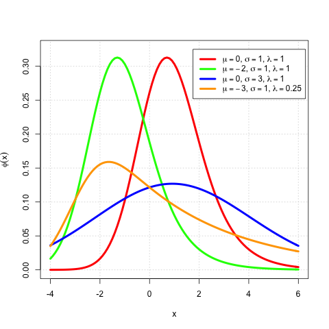

- redcapAPI An R interface to VUMC main data collection platform. Noteable for it’s use of [inversion of control](https://en.wikipedia.org/wiki/Inversion_of_control) when typecasting.
- [emg](https://github.com/spgarbet/emg/) A random mixture distribution of a Gaussian and an Exponential process for R.
- acepack Variance stabilization routines in R.
- yaml A [YAML 1.1](https://yaml.org/spec/1.1/) interface for R. A strong [dependency](https://xkcd.com/2347/) for the modern R community of packages.

## Endnotes

[This website](https://github.com/spgarbet/web) was made using basic [Markdown hosted on Github](https://www.andreashandel.com/posts/2021-01-11-simple-github-website/index.html) with [Tufte style](https://rstudio.github.io/tufte/).